# Capítulo 2: ISLR - Exercícios Aplicados

**c)** Os scatterplots não permitem visualizar nenhuma relação forte entre crime rate e as demais variáveis. Se observarmos a correlação desta variável com as demais, podemos observar que há uma relação positiva entre o índice de acessibilidade às estradas radiais (rad) e o valor inteiro da taxa de propriedade (tax) com o índice de criminalidade:

```r
cor(Boston)[,1]
```

```
##        crim          zn       indus        chas         nox          rm
##  1.00000000 -0.20046922  0.40658341 -0.05589158  0.42097171 -0.21924670
##         age         dis         rad         tax     ptratio       black
##  0.35273425 -0.37967009  0.62550515  0.58276431  0.28994558 -0.38506394
##       lstat        medv
##  0.45562148 -0.38830461
```

**d)** Plota boxplots dos índices de crime, imposto e da razão professor-aluno:

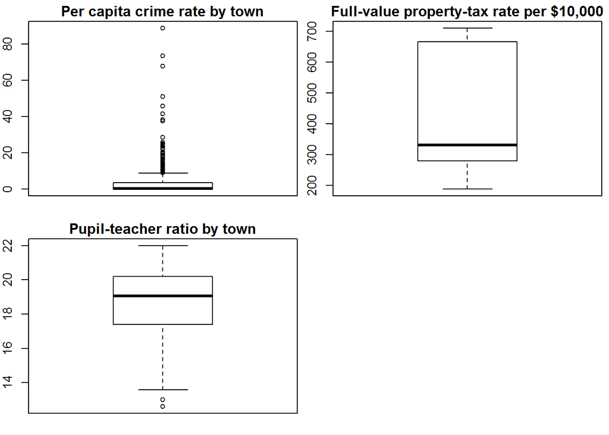

```r
par(mfrow=c(2,2), mar=c(1.5,2,1.5,0.5))
boxplot(Boston$crim, main = "Per capita crime rate by town")
boxplot(Boston$tax, main = "Full-value property-tax rate per $10,000")
boxplot(Boston$ptratio, main = "Pupil-teacher ratio by town")
```

Obtém informações sobre a extensão de cada uma das variáveis anteriores:

```r
range(Boston$crim)
```

```
## [1]  0.00632 88.97620
```

```r
range(Boston$tax)
```

```
## [1] 187 711
```

```r
range(Boston$ptratio)
```

```
## [1] 12.6 22.0
```

**e)**

```r
table(Boston$chas)
```

```
##
##   0   1
## 471  35
```

Observamos que 35 cidades estão ligadas ao rio Charles.

**f)**

```r
mean(Boston$ptratio)
```

```
## [1] 18.45553
```

A média da razão Professor-Aluno é de 18.46.

**g)** Identificação de qual cidade tem o menor valor médio de casas ocupadas:

```r
which.min(Boston$medv)
```

```
## [1] 399
```

Observação dos demais valores dos indicadores para a cidade em questão:

```r
Boston[which.min(Boston$medv),]
```

```
##        crim zn indus chas   nox    rm age    dis rad tax ptratio black
## 399 38.3518  0  18.1    0 0.693 5.453 100 1.4896  24 666    20.2 396.9
##     lstat medv
## 399 30.59    5
```

Resumo de cada um dos indicadores do banco:

```r
summary(Boston)
```

```
##       crim                zn             indus            chas
##  Min.   : 0.00632   Min.   :  0.00   Min.   : 0.46   Min.   :0.00000
##  1st Qu.: 0.08204   1st Qu.:  0.00   1st Qu.: 5.19   1st Qu.:0.00000
##  Median : 0.25651   Median :  0.00   Median : 9.69   Median :0.00000
##  Mean   : 3.61352   Mean   : 11.36   Mean   :11.14   Mean   :0.06917
##  3rd Qu.: 3.67708   3rd Qu.: 12.50   3rd Qu.:18.10   3rd Qu.:0.00000
##  Max.   :88.97620   Max.   :100.00   Max.   :27.74   Max.   :1.00000
##       nox               rm             age              dis
##  Min.   :0.3850   Min.   :3.561   Min.   :  2.90   Min.   : 1.130
##  1st Qu.:0.4490   1st Qu.:5.886   1st Qu.: 45.02   1st Qu.: 2.100
##  Median :0.5380   Median :6.208   Median : 77.50   Median : 3.207
##  Mean   :0.5547   Mean   :6.285   Mean   : 68.57   Mean   : 3.795
##  3rd Qu.:0.6240   3rd Qu.:6.623   3rd Qu.: 94.08   3rd Qu.: 5.188
##  Max.   :0.8710   Max.   :8.780   Max.   :100.00   Max.   :12.127
##       rad              tax           ptratio          black
##  Min.   : 1.000   Min.   :187.0   Min.   :12.60   Min.   :  0.32
##  1st Qu.: 4.000   1st Qu.:279.0   1st Qu.:17.40   1st Qu.:375.38
##  Median : 5.000   Median :330.0   Median :19.05   Median :391.44
##  Mean   : 9.549   Mean   :408.2   Mean   :18.46   Mean   :356.67
##  3rd Qu.:24.000   3rd Qu.:666.0   3rd Qu.:20.20   3rd Qu.:396.23
##  Max.   :24.000   Max.   :711.0   Max.   :22.00   Max.   :396.90
##      lstat            medv
##  Min.   : 1.73   Min.   : 5.00
##  1st Qu.: 6.95   1st Qu.:17.02
##  Median :11.36   Median :21.20
##  Mean   :12.65   Mean   :22.53
##  3rd Qu.:16.95   3rd Qu.:25.00
##  Max.   :37.97   Max.   :50.00
```

Comparando os índices desta cidade com a média e a extensão de cada um dos indicadores temos que a cidade de número 399 está acima da média nos indicadores de criminalidade, industrialização, concentração de óxidos de nitrogênio, idade (valor máximo), índice de acessibilidade às estradas radiais (valor máximo), razão Professor-Aluno, proporção de negros na cidade (valor máximo) e status baixo da população.

**h)** Identificação do número de subúrbios que têm em média mais de 7 e mais de 8 quartos por residência:

```r
nrow(subset(Boston, rm > 7))
```

```
## [1] 64
```

```r
nrow(subset(Boston, rm > 8))
```

```
## [1] 13
```

Temos um total de 64 cidades onde há uma média acima de 7 quartos por residência e um total de 13 cidades onde há uma média acima de 8 quartos por residência. Abaixo são exibidos os indicadores destas 13 cidades:

```r
subset(Boston, rm > 8)
```

```
##        crim zn indus chas    nox    rm  age    dis rad tax ptratio  black
## 98  0.12083  0  2.89    0 0.4450 8.069 76.0 3.4952   2 276    18.0 396.90
## 164 1.51902  0 19.58    1 0.6050 8.375 93.9 2.1620   5 403    14.7 388.45
## 205 0.02009 95  2.68    0 0.4161 8.034 31.9 5.1180   4 224    14.7 390.55
## 225 0.31533  0  6.20    0 0.5040 8.266 78.3 2.8944   8 307    17.4 385.05
## 226 0.52693  0  6.20    0 0.5040 8.725 83.0 2.8944   8 307    17.4 382.00
## 227 0.38214  0  6.20    0 0.5040 8.040 86.5 3.2157   8 307    17.4 387.38
## 233 0.57529  0  6.20    0 0.5070 8.337 73.3 3.8384   8 307    17.4 385.91
## 234 0.33147  0  6.20    0 0.5070 8.247 70.4 3.6519   8 307    17.4 378.95
## 254 0.36894 22  5.86    0 0.4310 8.259  8.4 8.9067   7 330    19.1 396.90
## 258 0.61154 20  3.97    0 0.6470 8.704 86.9 1.8010   5 264    13.0 389.70
## 263 0.52014 20  3.97    0 0.6470 8.398 91.5 2.2885   5 264    13.0 386.86
## 268 0.57834 20  3.97    0 0.5750 8.297 67.0 2.4216   5 264    13.0 384.54
## 365 3.47428  0 18.10    1 0.7180 8.780 82.9 1.9047  24 666    20.2 354.55
##     lstat medv
## 98   4.21 38.7
## 164  3.32 50.0
## 205  2.88 50.0
## 225  4.14 44.8
## 226  4.63 50.0
## 227  3.13 37.6
## 233  2.47 41.7
## 234  3.95 48.3
## 254  3.54 42.8
## 258  5.12 50.0
## 263  5.91 48.8
## 268  7.44 50.0
## 365  5.29 21.9
```